# Taller Introductorio al uso de R Studio- Clase 3

## Retomemos

## Contenidos

[figure not shown]

- Instalación de software
- Ventajas/Desventajas de R y RStudio
- Entorno de trabajo
- Objetos de trabajo
- Instalación de Paquetes estadísticos
- Tipos de Variables
- Valores Especiales
- **Recursos en línea**
- Importar Datos de Fuentes Externas
- Estadística Descriptiva Básica
- Configuración de datos

## Recursos en-línea

### Cursos

- *DataCamp*. Por ejemplo, Introduction to R (https://www.datacamp.com/courses/free-introduction-to-r)
- Si usted quiere tener una prueba gratis de DataCamp, más allá de completar el primer capítulo de un curso (https://www.c-sharpcorner.com/blogs/steps-to-activate-free-access-to-datacamp-pulralsight-linkedin-learning-etc-through-visual-studio-dev-essentials-program)
- *Statistics With Interactive R Learning(SWIRL)*: The easiest and the most interactive way to start learning R (https://swirlstats.com/students.html).
- *edX*. Por ejemplo, Dat Science: R Basics (https://www.edx.org/es/course/data-science-r-basics), o Introduction to R for Data Science (https://www.edx.org/es/course/introduction-to-r-for-data-science-2).
- *YouTube*. Por ejemplo, Estadística Útil (https://www.youtube.com/watch?v=rzw1E6HxBFY&list=PLfX5C7cc6LRJ7V6WNgatRQJ6PNMrb4zfM)
- *Estación Lastarria* (https://www.estacionlastarria.cl/actividades/rstudio/rstudio-ciencias-sociales.html)
- *Centro de Microdatos UChile* (https://www.microdatos.cl/analisis-datos-r)
- *Introduction to R* (https://www.quantargo.com/courses/course-r-introduction/)

### Comunidades

- *R-Ladies*
- *StackOverflow* (https://es.stackoverflow.com/). Por ejemplo, Testeo de modelo lineal en R (https://es.stackoverflow.com/questions/331075/testeo-de-modelo-lineal-en-r)
- *UseRChile* Usuarios de R en Chile (https://userchile.cl/)

### Otros

- learnr (Etiqueta “Tutorial”)
- Statistics With Interactive R Learning (SWIRL)
- CheatSheets. https://rstudio.com/resources/cheatsheets/
- Memes
- Twitter, Pachá (@pachamaltese) y Hadley Wickham (@hadleywickham)
- Rpubs. Páginas alojadas que permiten ver cómo cada persona obtuvo un determinado producto a partir de un código

## Importar Datos de Fuentes Externas

- Rstudio tiene una opción para incorporar bases de datos de manera más fácil

[figure not shown]

- Existen muchos tipos de datos (.csv, .sav, .Rds, .xlsx, etc.)
- En este caso, vamos a ver el CSV (archivo de texto separado por comas)
- Pero puede estar separado por distintos caracteres (“;”, “,”, “\ t o TAB” )
- Los elementos que definen a una importación de un csv que hay que tener en consideración son los siguientes:
  - Elemento separador de celdas
  - Norma de codificación de texto (UTF-8, Latin1,etc.)
  - Punto de partida de recogida de datos
  - ¿Primera fila como nombre de las columnas?
  - Separador de Decimales

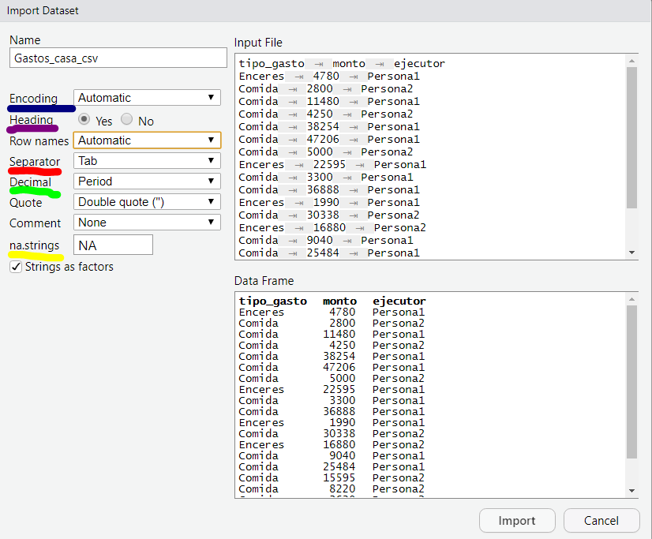

- Cargue la base de datos enviada por correo electrónico (si no le llegó, bájela por [aquí](https://raw.githubusercontent.com/AGSCL/Curso_R/master/Gastos_casa_csv.txt).

```r
#Gastos_casa_csv <- read.delim("G:/Mi unidad/Alvacast/Curso/Gastos_casa_csv.txt")
#
##CADA UNO DEBE CAMBIAR LA RUTA DE OBTENCIÓN DEL ARCHIVO, DEPENDIENDO DEL DIRECTORIO DONDE LO GUARDOÓ. SE ACONSEJA GUARDARLO EN LA MISMA CARPETA QUE EL PROYECTO.

Gastos_casa_csv <- read.delim(gsub("0c963a043f92e3c567b6afb48d406df5a2f38f5c/","",paste0(getwd(),"/","Gastos_casa_csv.txt")))
```

## Estadística Descriptiva Básica

### Medidas de Tendencia Central

```r
mean(Gastos_casa_csv$monto, na.rm=T) #Utilizar este argumento para omitir los casos perdidos.
```

```
## [1] 18848.02
```

```r
median(Gastos_casa_csv$monto, na.rm=T) #Utilizar este argumento para omitir los casos perdidos.
```

```
## [1] 16752.5
```

- En el caso de la moda necesitaremos aplicar una función, que tomará todos los valores únicos de un determinado vector, y que obtendrá el que posee la mayor cantidad de observaciones del vector que calzan con el valor único.

```r
Mode <- function(x) {
  ux <- unique(x)
  ux[which.max(tabulate(match(x, ux)))]
}
gastos_casa_csv_2<-cbind(Gastos_casa_csv, monto_en_miles=round(Gastos_casa_csv$monto/1000,0))
Mode(gastos_casa_csv_2$monto_en_miles)
```

```
## [1] NA
```

- ¿Qué ocurrió con los resultados? Esta función no tiene la opción de remover valores perdidos, por lo que una opción plausible será ingresar una base de datos sin valores perdidos (“listwise deletion of missing values”).

```r
gastos_casa_csv_2_naomit<-na.omit(gastos_casa_csv_2) #
Mode(gastos_casa_csv_2_naomit$monto_en_miles)
```

```
## [1] 6
```

```r
#nrow(Gastos_casa_csv)
#nrow(Gastos_casa_csv)
```

- ¿Qué hizo la función na.omit?. lo mismo que `Mode(gastos_casa_csv_2[-c(231:1226),4])`. **Analicen qué se hizo aquí**

## Variaciones descriptivas

- Modo dplyr

```r
library(dplyr)
#usted puede personalizarlo de acuerdo a sus intereses
gastos_casa_csv_2_naomit %>%
  summarise(promedio=mean(monto_en_miles, na.rm=T), #no es necesario na.rm, porque ya estamos utilizando la base de datos sin NA's
            mediana= median(monto_en_miles, na.rm=T),
            moda= Mode(monto_en_miles),
            p25= quantile(monto_en_miles,.25, na.rm=T), #percentil 25
            p75= quantile(monto_en_miles,.75, na.rm=T), #percentil 75
            min= min(monto_en_miles, na.rm=T),
            max= max(monto_en_miles, na.rm=T),
            valores_unicos= length(unique(monto_en_miles))
            )
```

```
##   promedio mediana moda p25 p75 min max valores_unicos
## 1 18.83043      17    6   8  26   0 136             50
```

- ¿Y por contribuyente?

```r
library(dplyr)
#usted puede personalizarlo de acuerdo a sus intereses
gastos_casa_csv_2_naomit %>%
  dplyr::group_by(ejecutor) %>%  #PRIMERO AGRUPAMOS POR CONTRIBUYENTE
  summarise(promedio=mean(monto_en_miles, na.rm=T), #no es necesario na.rm, porque ya estamos utilizando la base de datos sin NA's
            mediana= median(monto_en_miles, na.rm=T),
            moda= Mode(monto_en_miles), #miren, ocupamos la función que hicimos con anterioridad
            p25= quantile(monto_en_miles,.25, na.rm=T), #percentil 25
            p75= quantile(monto_en_miles,.75, na.rm=T), #percentil 75
            min= min(monto_en_miles, na.rm=T),
            max= max(monto_en_miles, na.rm=T),
            valores_unicos= length(unique(monto_en_miles))
            )
```

```
## # A tibble: 2 x 9
##   ejecutor promedio mediana  moda   p25   p75   min   max valores_unicos
## * <chr>       <dbl>   <dbl> <dbl> <dbl> <dbl> <dbl> <dbl>          <int>
## 1 Persona1     22.7    22.5    14  11.8    31     1    72             43
## 2 Persona2     14.9    11       6   6      18     0   136             34
```

- Otro software

```r
library(psych)
psych::describe(gastos_casa_csv_2_naomit$monto)
```

```
##    vars   n     mean       sd  median  trimmed      mad min    max  range skew
## X1    1 230 18848.02 15116.03 16752.5 16982.43 13141.77 500 136361 135861  2.7
##    kurtosis     se
## X1     15.3 996.72
```

- y agrupar por contribuyente

```r
library(psych)
psych::describeBy(gastos_casa_csv_2_naomit$monto, group=gastos_casa_csv_2_naomit$ejecutor)
```

```
##
##  Descriptive statistics by group
## group: Persona1
##    vars   n     mean       sd  median  trimmed      mad  min   max range skew
## X1    1 116 22700.03 13487.96 22387.5 21803.49 14845.27 1360 72000 70640 0.75
##    kurtosis      se
## X1     0.78 1252.33
## ------------------------------------------------------------
## group: Persona2
##    vars   n     mean       sd median  trimmed     mad min    max  range skew
## X1    1 114 14928.43 15721.93  11000 12464.33 8625.03 500 136361 135861 4.56
##    kurtosis      se
## X1     29.9 1472.49
```

```r
#Para mayor información, consultar https://www.rdocumentation.org/packages/psych/versions/2.0.12/topics/describeBy
```

```r
library(Hmisc)
#No permite compararlo por grupos, por lo que dividimos la base de datos por persona.
Hmisc::describe(~ monto, data= gastos_casa_csv_2_naomit[gastos_casa_csv_2_naomit$ejecutor=="Persona1",])
```

```
## monto
##
##  1  Variables      116  Observations
## --------------------------------------------------------------------------------
## monto
##        n  missing distinct     Info     Mean      Gmd      .05      .10
##      116        0      108        1    22700    15031     4502     5975
##      .25      .50      .75      .90      .95
##    11657    22388    31262    38664    42373
##
## lowest :  1360  1990  3300  3431  3702, highest: 47206 53550 59200 60883 72000
## --------------------------------------------------------------------------------
```

```r
Hmisc::describe(~ monto, data= gastos_casa_csv_2_naomit[gastos_casa_csv_2_naomit$ejecutor=="Persona2",])
```

```
## monto
##
##  1  Variables      114  Observations
## --------------------------------------------------------------------------------
## monto
##        n  missing distinct     Info     Mean      Gmd      .05      .10
##      114        0       91        1    14928    12913     2520     4075
##      .25      .50      .75      .90      .95
##     6041    11000    17917    26399    33531
##
## lowest :    500   1500   2000   2800   3200, highest:  39562  42882  53500  66986 136361
## --------------------------------------------------------------------------------
```

```r
#Para mayor información, consultar https://www.rdocumentation.org/packages/Hmisc/versions/3.0-0/topics/describe
```

- Paquetes para explorar más allá de este curso: comparegroups, tableone, codebook, etc.

## Gráficos Básicos

### Histogramas

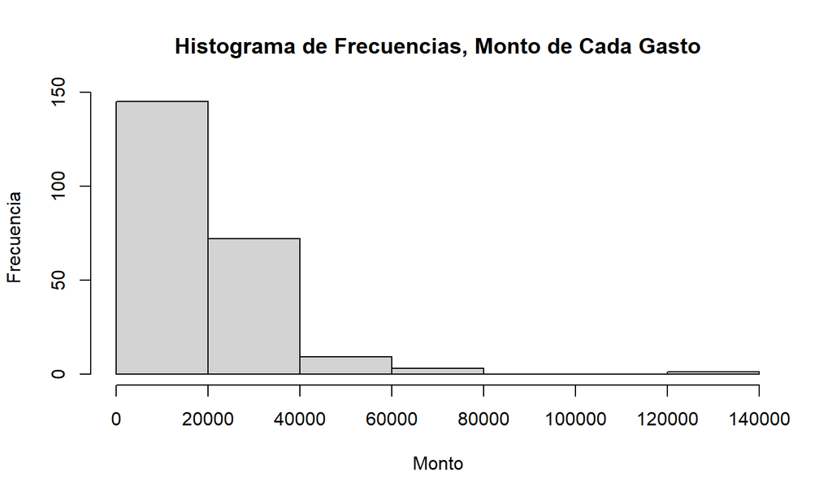

```r
hist(Gastos_casa_csv$monto, main= "Histograma de Frecuencias, Monto de Cada Gasto", xlab="Monto", ylab="Frecuencia")
```

- A simple vista, distribución leptocúrtica y asimétrica a la derecha
- Corroborar con curtosis/kurtosis y sesgo/skewness (psych::describe) (umbrales dependen del autor que utilice para argumentarlo y las características/contexto de cada conjunto de datos)
- ¿Pero quién gasta más? ¿La persona 1 o la 2?

### Diagrama de Cajas

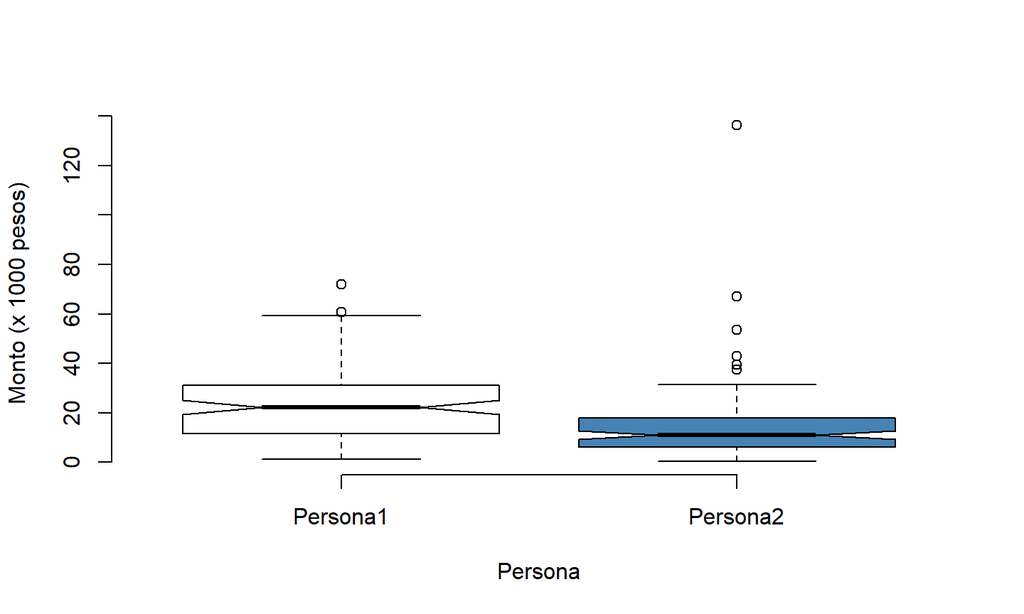

```r
boxplot(monto ~ ejecutor,  #FORMATO FÓRMULA
        data = Gastos_casa_csv %>%
          dplyr::mutate(monto=monto/1000), #Ojo, si se fijan el formato del ingreso de los datos para este gráfico,
        # se encuentra la variable dependiente (Y) y la variable independiente (X)
        # además no es necesario indicar para cada variable el origen de la base
        #de igual manera, permite modificar la variable dependiente, en este caso, dividirlo por 1000 pesos
        frame = FALSE,
        notch = TRUE,
        xlab= "Persona",
        ylab="Monto (x 1000 pesos)", #etiquetas
        col = c("white", "steelblue")) #etiquetas
```

- Ojo con el papel de la virgulilla (`~`)
- Boxplot: IQR (cajas), bigotes (primer cuartil /tercer cuartil/ 1.5 * IQR si hay puntos alejados), puntos alejados (anomalías o *outliers*)
- Existen otro tipo de paquetes estadísticos para gráficos más complejos y amigables

### Gráfico de Barras

- Sirve para variables categóricas. No obstante, para ello, debemos utilizar una matriz de recuentos por categoría

```r
asistentes_curso_2020 <- data.frame(condicion=c("Estudiante Doctorado",".","Académico", "Funcionario", "Estudiante Doctorado",".", "Estudiante Doctorado", "Académico", "Funcionario", ".", "Estudiante"),asistencia=c(4, 4, 2, 2, 4, 3, 4, 1, 4, 2, 4))
str(asistentes_curso_2020)
```

```
## 'data.frame':    11 obs. of  2 variables:
##  $ condicion : chr  "Estudiante Doctorado" "." "Académico" "Funcionario" ...
##  $ asistencia: num  4 4 2 2 4 3 4 1 4 2 ...
```

```r
#Exploramos los valores que puede adoptar esta columna
unique(asistentes_curso_2020$condicion)
```

```
## [1] "Estudiante Doctorado" "."                    "Académico"
## [4] "Funcionario"          "Estudiante"
```

```r
#Obtenemos una tabla
table(asistentes_curso_2020$condicion)
```

```
##
##                    .            Académico           Estudiante
##                    3                    2                    1
## Estudiante Doctorado          Funcionario
##                    3                    2
```

- Tenemos una condición ausente (“.”)
- Tenemos otra etiqueta que no cabrá en el gráfico de barras y no aparecerá

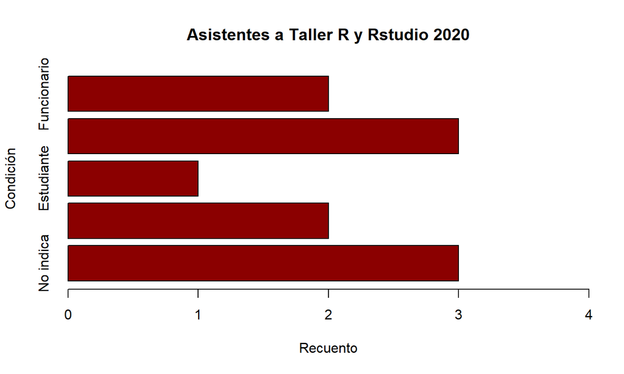

```r
#OPC1. R Base, Tabla

bp<-
barplot(table(asistentes_curso_2020$condicion),
        col = "darkred", #color de las barras
        main= "Asistentes a Taller R y Rstudio 2020", #título
        xlab= "Recuento", #etiqeuta
        names.arg = c("No indica", "Académico", "Estudiante", "Estudiante Doc", "Funcionario"), #definimos etiquetas
        ylab= "Condición", #si se fijan, las etiquetas están rotadas
        horiz=T, #El argumento permite rotar la tabla
        beside=T,
        xlim=c(0,4) #le damos un poco más de espacio
        )
```

```r
bp #desplegar el objeto
```

```
##      [,1]
## [1,]  0.7
## [2,]  1.9
## [3,]  3.1
## [4,]  4.3
## [5,]  5.5
```

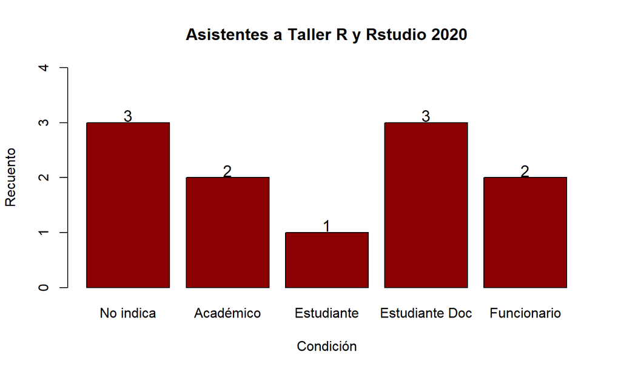

```r
#OPC2. dplyr
library(dplyr)
asistentes_curso_2020_dplyr<-
asistentes_curso_2020 %>%
  dplyr::group_by(condicion) %>%
  dplyr::count(condicion)

bp2<-
  barplot(n ~ condicion,
          data=asistentes_curso_2020_dplyr,
          col = "darkred",
          main= "Asistentes a Taller R y Rstudio 2020",
          ylab= "Recuento",
          names.arg = c("No indica", "Académico", "Estudiante", "Estudiante Doc", "Funcionario"),
          xlab= "Condición",
          ylim=c(0,4)
          )
  #Añadimos una etiqueta
text(bp2,  #objeto de imagen sobre el cual superponer el texto
     as.numeric(table(asistentes_curso_2020$condicion))+.13, #ubicación del texto en el eje (.05 más arriba)
     labels= format(as.numeric(table(asistentes_curso_2020$condicion))),
     xpd = TRUE,  #permite que las etiquetas que escapan de los límites de los ejes se mantengan
     cex = 1.2, #factor de expansión de texto (1 es la base, aumentamos un 20%)
     col = "black")
```

## Configuración de Datos

- Bajar [BASE DE DATOS](https://raw.githubusercontent.com/AGSCL/Curso_R/master/0c963a043f92e3c567b6afb48d406df5a2f38f5c/coronavirus.xlsx)

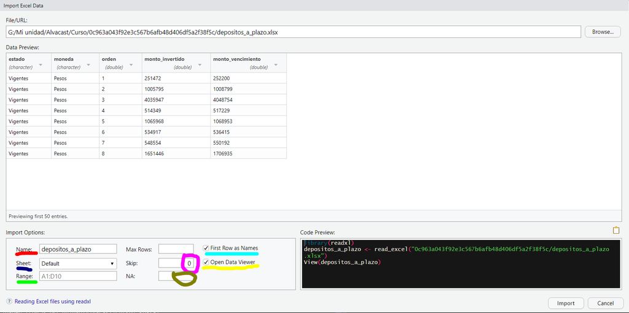

- Los elementos que definen a una importación de un excel (*.xlsx) que hay que tener en consideración son los siguientes:

  -Nombre que se le asignará a base de datos

  -Nombre de la hoja de excel que se quiere importar a R

  -Rango de datos (para evitar lo que ocurrió con los gastos de la casa)

  -saltar algunas filas hasta llegar al nombre de las columnas (generalmente útil si las primeras filas no son de utilidad para diferenciar los datos, como el nombre del autor, la fecha,o nombres de un conjunto de filas, etc.)

  -NA (cómo se tratan los valores perdidos)

## Configuración de Datos(2)

```r
#Gracias al repositorio de CSSE at Johns Hopkins University (https://raw.githubusercontent.com/CSSEGISandData/COVID-19/master/csse_covid_19_data/csse_covid_19_time_series/time_series_covid19_confirmed_global.csv)
library(readxl)
coronavirus <- read_excel(
  paste0(getwd(),"/","coronavirus.xlsx"),
  #"G:/Mi unidad/Alvacast/Curso/0c963a043f92e3c567b6afb48d406df5a2f38f5c/coronavirus.xlsx",
    sheet = "Hoja1"
  )
# exploramos la base de datos
dplyr::glimpse(coronavirus)
```

```
## Rows: 4
## Columns: 400
## $ `"measure"`        <chr> "confirmed", "confirmed", "deaths", "deaths"
## $ `"Province/State"` <lgl> NA, NA, NA, NA
## $ `"Country/Region"` <chr> "Chile", "Argentina", "Chile", "Argentina"
## $ `"1/22/20"`        <dbl> 0, 0, 0, 0
## $ `"1/23/20"`        <dbl> 0, 0, 0, 0
## $ `"1/24/20"`        <dbl> 0, 0, 0, 0
## $ `"1/25/20"`        <dbl> 0, 0, 0, 0
## $ `"1/26/20"`        <dbl> 0, 0, 0, 0
## $ `"1/27/20"`        <dbl> 0, 0, 0, 0
## $ `"1/28/20"`        <dbl> 0, 0, 0, 0
## $ `"1/29/20"`        <dbl> 0, 0, 0, 0
## $ `"1/30/20"`        <dbl> 0, 0, 0, 0
## $ `"1/31/20"`        <dbl> 0, 0, 0, 0
```

[output cut: 387 more lines]

```r
# descartamos una columna
coronavirus$`"Province/State"`<- NULL
#limpiamos los nombres
coronavirus <- janitor::clean_names(coronavirus)
```

- El formato es problemático. Cada fila es una columna. Parecen ser las fechas
- Datos de Ancho y largo (`reshape()`)

```r
library(readr)

resh_covid19<-
  stats::reshape(coronavirus,
                        varying = 3:length(coronavirus), #los datos que cambian, es decir las columnas concernientes a las fechas
                        timevar = "date", #nombre de la columna que agrupa a los nombres de los datos que cambiaban
                        idvar = 1:2, #las variables que no debiesen cambiar a partir de las fechas
                        direction= "long", # datos de ancho a largo
                        #v.names = "value",# nombre de la columna que agrupa a los valores contenidos en las columnas originales de los datos que cambiaban
                        sep = "x") %>%
            dplyr::rename("value"="") %>%  #Renombrar el nombre de la columna ausente
            dplyr::mutate(date=parse_date(date, format="%m_%d_%y")) %>%  #reconocerá el mes en un número de 2 caracteres numéricos, separado por "_", seguido del día en 2 caracteres numéricos y también separados por comas, más el año también escrito en 2 caracteres numéricos. Esto lo transformará automáticamente en formato fecha.
            dplyr::mutate(measure=factor(measure, labels=c("confirmed","deaths"))) #Hacemos que esta variable se defina con formato factor y adopte 2 valores: "confirmado/confirmed" y "muertes/deaths"

# FUENTE
#https://www.r-bloggers.com/2013/02/converting-a-dataset-from-wide-to-long/
```

- Pero yo quiero separar el recuento por medida (entre muertos y confirmados).

```r
resh_covid19_wide_measure <-
stats::reshape(
as.data.frame(resh_covid19), #preferimos adaptar la base de datos a formato data.frame y no tibble porque genera errores con stats::reshape
  timevar="measure", #la medida que estará sujeta a ensanchamiento o división por columnas
  idvar=c("country_region","date"), #variables que no cambian
  direction="wide" #de largo a ancho
)

glimpse(resh_covid19_wide_measure)
```

```
## Rows: 794
## Columns: 4
## $ country_region  <chr> "Chile", "Argentina", "Chile", "Argentina", "Chile"...
## $ date            <date> 2020-01-22, 2020-01-22, 2020-01-23, 2020-01-23, 20...
## $ value.confirmed <dbl> 0, 0, 0, 0, 0, 0, 0, 0, 0, 0, 0, 0, 0, 0, 0, 0, 0, ...
## $ value.deaths    <dbl> 0, 0, 0, 0, 0, 0, 0, 0, 0, 0, 0, 0, 0, 0, 0, 0, 0, ...
```

## Configuración de Datos(3)

- Gráfico de Dispersión

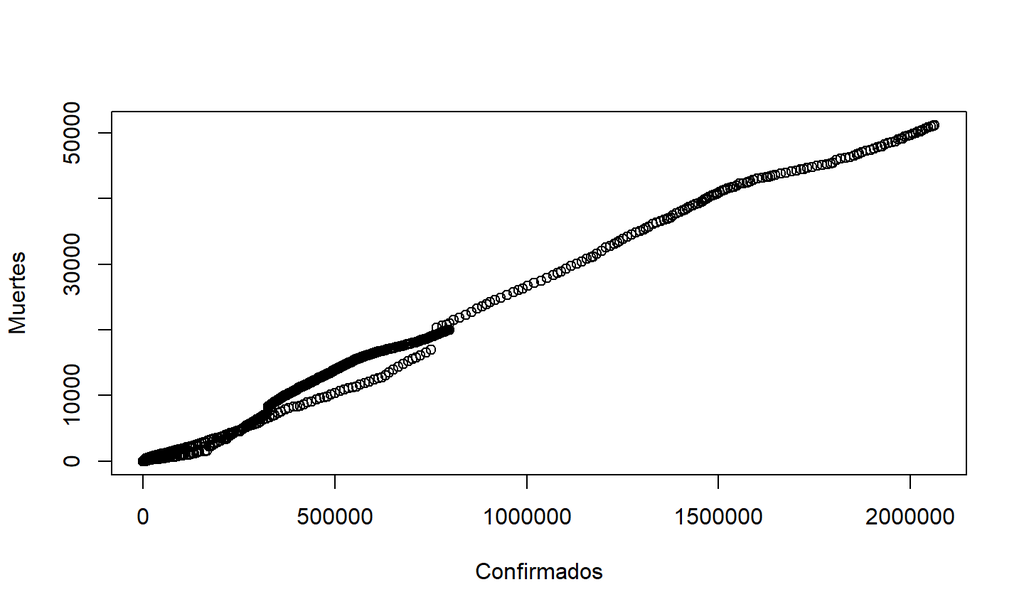

```r
plot(resh_covid19_wide_measure$value.confirmed,resh_covid19_wide_measure$value.deaths, xlab="Confirmados",ylab="Muertes")
```

- Esto se ve extraño. ¿Recuerdas que tenemos tanto a Chile como Argentina?

[output not shown]

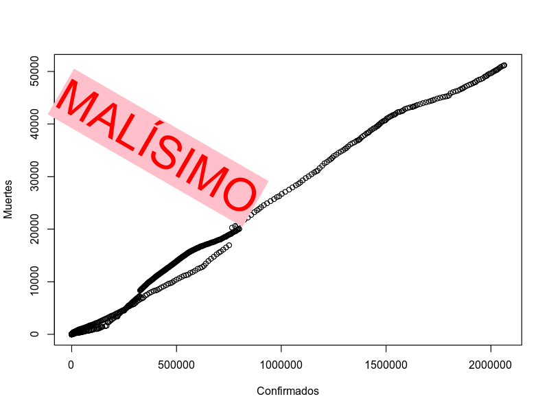

- Dividimos los datos (subset)

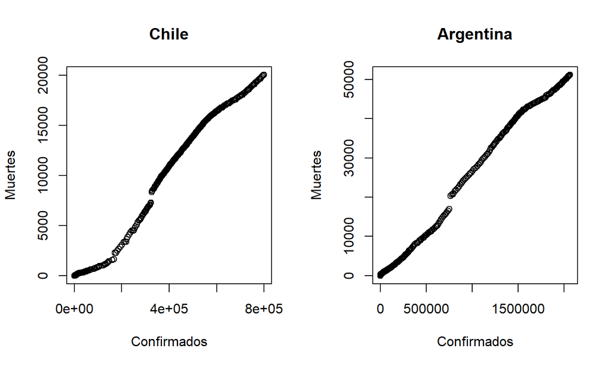

```r
par(mfrow=c(1,2)) #combinamos 2 gráficos en una fila, pero dividimos la columna en 2

#primer gráfico
plot(resh_covid19_wide_measure[which(resh_covid19_wide_measure$country_region=="Chile"),"value.confirmed"], #seleccionamos aquellas (which) filas del vector país de la base de datos que es igual a "Chile", y seleccionamos como columna el valor "value.confirmed"
     resh_covid19_wide_measure[which(resh_covid19_wide_measure$country_region=="Chile"),"value.deaths"], #seleccionamos aquellas (which) filas del vector país de la base de datos que es igual a "Chile", y seleccionamos como columna el valor "value.deaths"
     xlab="Confirmados",ylab="Muertes", main= "Chile") #etiquetamos las dimensiones y el gráfico

#segundo gráfico
plot(resh_covid19_wide_measure[which(resh_covid19_wide_measure$country_region=="Argentina"),"value.confirmed"], #seleccionamos aquellas (which) filas del vector país de la base de datos que es igual a "Argentina", y seleccionamos como columna el valor "value.confirmed"
     resh_covid19_wide_measure[which(resh_covid19_wide_measure$country_region=="Argentina"),"value.deaths"], #seleccionamos aquellas (which) filas del vector país de la base de datos que es igual a "Argentina", y seleccionamos como columna el valor "value.deaths"
     xlab="Confirmados",ylab="Muertes", main="Argentina") #etiquetamos las dimensiones y el gráfico
```

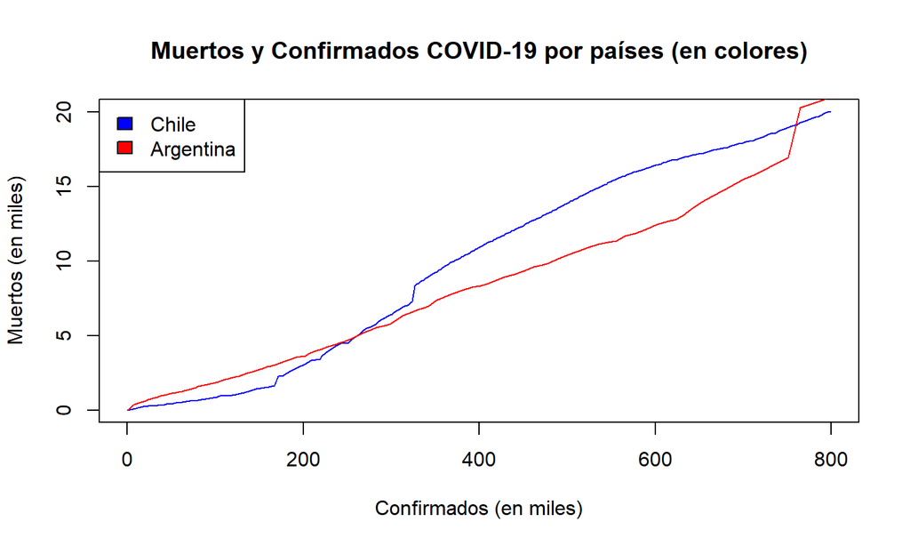

```r
plot(resh_covid19_wide_measure[which(resh_covid19_wide_measure$country_region=="Chile"),"value.confirmed"]/1000, #para que sea más claro, los dividimos por 1000
     resh_covid19_wide_measure[which(resh_covid19_wide_measure$country_region=="Chile"),"value.deaths"]/1000,
main="Muertos y Confirmados COVID-19 por países (en colores)",
ylab="Muertos (en miles)",
xlab="Confirmados (en miles)",
type="l",
col="blue") #color azul
lines(resh_covid19_wide_measure[which(resh_covid19_wide_measure$country_region=="Argentina"),"value.confirmed"]/1000, #Añadimos una segunda línea con argentina, en rojo
     resh_covid19_wide_measure[which(resh_covid19_wide_measure$country_region=="Argentina"),"value.deaths"]/1000,
     col="red", #color rojo
     ylab="Muertos (en miles)",
     xlab="Confirmados (en miles)")
legend("topleft", #definimos una leyenda de los datos, ubicado arriba a la izquierda
c("Chile","Argentina"),
fill=c("blue","red")
)
```

- Limitaciones: en términos analíticos este gráfico no dice mucho. Cuidado con las interpretaciones.

## Fuentes

- Codementor Community (2018, Nov 26). Learn R Online. Obtenido desde: https://www.codementor.io/collections/learn-r-online-bwbcv0nx4
- Illinois Library (2020, Feb 12). Introduction to R: Getting Data from a CSV file. Obtenido desde: http://guides.library.illinois.edu/c.php?g=347944&p=2345554
- Tutorialspoint. Mean, Median and Mode. https://www.tutorialspoint.com/r/r_mean_median_mode.htm
- Dugar, D. (2018, Aug. 23). Skew and Kurtosis: 2 Important Statistics terms you need to know in Data Science. Codeburst.io. https://codeburst.io/2-important-statistics-terms-you-need-to-know-in-data-science-skewness-and-kurtosis-388fef94eeaa
- Introducción a Data Science: Programación Estadística con R. https://www.coursera.org/learn/intro-data-science-programacion-estadistica-r?ranMID=40328&ranEAID=Jsa5%2F1hgYik&ranSiteID=Jsa5_1hgYik-2ohj13Hsri.l561_Ekbdtg&siteID=Jsa5_1hgYik-2ohj13Hsri.l561_Ekbdtg&utm_content=15&utm_medium=partners&utm_source=linkshare&utm_campaign=Jsa5%2F1hgYik
- Codecademy. Introduction to R. https://www.codecademy.com/courses/learn-r/lessons/introduction-to-r/exercises/why-r.
- DataCamp. Introducción a R. https://www.datacamp.com/community/open-courses/introduccion-a-r
- DataCamp. R for the Intimidated. https://www.datacamp.com/community/open-courses/r-for-the-intimidated
- Schmidt, P. (2021, Febrero 24). Doing Row-wise Operations the Column-wise Way With tidyr pivot_longer. R-bloggers. https://www.r-bloggers.com/2021/02/doing-row-wise-operations-the-column-wise-way-with-tidyr-pivot_longer/

## Ejercicio

- Acceda a la base de datos de Nivel Regional MINSAL(Créditos a Iván González, github.com/ivanMSC/COVID19_Chile)
- Previsualicemos los datos: https://raw.githubusercontent.com/ivanMSC/COVID19_Chile/master/covid19_chile.csv
- Generemos una carpeta en escritorio, de nombre “COVID19_CL_REG”
- Genere un proyecto con el mismo nombre
- Cargarla en R y conviertala en un data frame, asignándole el siguiente nombre “COVID19_CL_REG”.
- obtener la media y la mediana de `Nuevo Confirmado` por `Region` (2da y 3ra columnas)
- Obtenga la media y la mediana sin el total (fila 15)
- ¿Qué región en promedio obtuvo en segundo lugar más nuevos casos confirmados?
- ¿Esta diferencia se repite al obtener la mediana?

## Prueba Final

## Instrucciones Prueba Final (A entregar el próximo Lunes)

- Favor descargar esta base de datos: https://github.com/AGSCL/Install-R/raw/master/personal_curso.xlsx
- Cargarla en RStudio, y enviar a gonzalez.santacruz.andres@gmail.com, un gráfico de dispersión de decimal2 en contraste con /en función del decimal1.
- Adjunte también un diagrama de cajas (boxplot), de entero1 por sexo. Esriba una interpretación (busque en internet)
- Sus resultados debiesen coincidir con los hallazgos CORRECTOS presentados en la siguiente página: https://agscl2.shinyapps.io/shiny_app/
- Una vez hecho lo anterior, favor responder esta [encuesta anónima](https://forms.gle/mQH6S2tHd22BKbYb9) (no se solicitará identificarse)